# Ejemplos de Análisis de Factores

Jorge de la Vega

29 de septiembre de 2018

En este laboratorio la intención es practicar el análisis exploratorio de factores (AF). Los siguientes paquetes son útiles en AF:

```r
options(width=150)
library(corrplot) #hacer gráficas informativas de una matriz de correlaciones.
library(psych)    #funciones relevantes para PCA y FA
# library(FactoMineR)  #Se puede  utilizar para mejorar las gráficas mostradas-
```

# Ejemplo: datos de biblioteca

Este ejemplo utiliza datos de Thomspon[2004]. Los datos corresponden a una muestra aleatoria de un estudio sobre la percepsión de los usuarios en la calidad del servicio de las librerías académicas en los Estados Unidos y Canadá. Se miden 12 variables en 100 estudiantes graduados y 100 profesores. Los datos están en el archivo *Encuesta.csv*.

Los datos corresponden a las siguientes definiciones:

id: id del caso, RoleType: estudiante (2) o facultad (3) p1: Disposición de apoyar a los usuarios p2: Dar a los usuarios atención individualizada p3: Los empleados que tienen trato con los usuarios son cuidadosos p4: Los empleados son consistentemente cortéses p5: Un paraíso de quietud y soledad p6: Un lugar meditativo p7: Un ambiente contemplativo p8: Espacio que facilita el estudio silencioso p9: Colecciones impresas completas p10: Títulos de revistas es completo p11: La biblioteca interdisciplinaria requiere ser atendida p12: Préstamo interbibliotecario/ envío oportuno de documentos

```r
datos <- read.csv("../data/Encuesta.csv")
head(datos) #muestra los primeros datos de la matriz
```

```
  id RoleType p1 p2 p3 p4 p5 p6 p7 p8 p9 p10 p11 p12
1  1        2  8  7  5  5  3  2  3  3  6   5   5   7
2  2        2  5  7  5  5  4  5  5  6  3   4   3   6
3  3        2  6  5  5  6  5  3  5  3  3   5   4   7
4  4        2  5  5  4  6  4  4  4  4  2   1   5   4
5  5        2  5  5  5  5  5  4  6  2  4   4   5   7
6  6        2  7  7  7  8  7  8  7  6  6   8   7   5
```

```r
id <- datos[,1]
RoleType <- datos[,2]
datos <- datos[,-(1:2)] # redefinimos el conjunto para tener solo las preguntas del cuestionario
```

En el presente ejemplo, consideraré la Estrategia de aplicación de AF que se mencionó en la clase, y agregaré un par de verificaciones adicionales que pueden ser útiles. Lo primero a hacer es revisar la matriz de correlaciones de los datos. Se ha comentado que si no hay correlaciones significativas entre las variables, entonces no tiene mucho sentido aplicar el AF o CP. Vamos a considerar visualizar las variables correlacionadas:

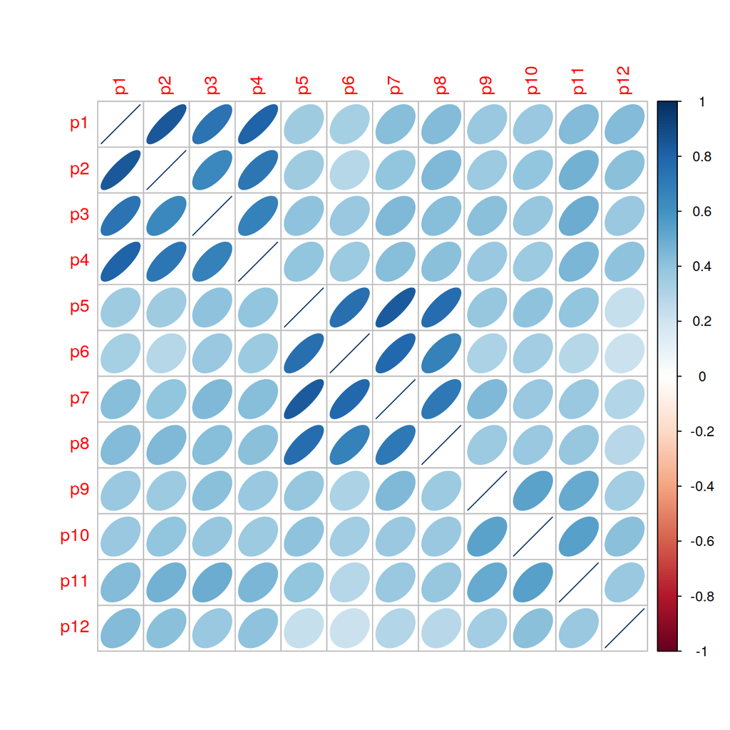

```r
corrplot(corr=cor(datos),method="ellipse")
```

Adicional a la visualización de la correlación, podemos aplicar dos pruebas adicionales:

1. la prueba de esfericidad de Bartlett para probar $H_0: cor(X) = I_p \quad vs \quad H_a:cor(X)\neq I_p$ (agregada su descripción a la presentación sobre el tema de AF).
2. La prueba KMO (Kaiser-Meyer-Olkin) de adecuación de la muestra. La prueba mide la adecuación muestral de cada variable en el modelo y de todo el modelo completo.

```r
#Pruebas de esfericidad:

bartlett.test(datos) #directa en stats
```

```
    Bartlett test of homogeneity of variances

data:  datos
Bartlett's K-squared = 39.891, df = 11, p-value = 3.734e-05
```

```r
cortest.bartlett(cor(datos),n=200) # opción en psych de la prueba de esfericidad++++
```

```
$chisq
[1] 1647.985

$p.value
[1] 1.12493e-300

$df
[1] 66
```

```r
#Prueba KMO: El rango para evaluarlo se puede ver en la ayuda de la función:
# In his delightfully flamboyant style, Kaiser (1975) suggested that
# KMO > .9 were marvelous,
# in the .80s, mertitourious,
# in the .70s, middling,
# in the .60s, medicore,
# in the 50s, miserable, and
# less than .5, unacceptable.
KMO(cor(datos))
```

```
Kaiser-Meyer-Olkin factor adequacy
Call: KMO(r = cor(datos))
Overall MSA =  0.89
MSA for each item =
  p1   p2   p3   p4   p5   p6   p7   p8   p9  p10  p11  p12
0.82 0.88 0.94 0.92 0.86 0.90 0.87 0.93 0.91 0.89 0.91 0.95
```

De acuerdo a las estadísticas mostradas, ambas pruebas corroboran que se puede aplicar el análisis factorial a los datos.

Una vez validada la viabilidad del análisis, se sugiere realizar un análisis de factores basado en componentes principales. Este caso se realizará de dos maneras: 1. A “mano” 2. Usando las funciones ya definidas en los paquetes.

## FA a mano usando componentes principales

Obtenemos las componentes principales y consideramos aquellas componentes que tengan varianza mayor al promedio de los eigenvalores de la matriz de covarianzas (o en el caso de usar correlación, usamos las componentes que sean mayores que 1) Utilizaremos para este ejercicio la matriz de correlaciones.

```r
R <- cor(datos)  #matriz de correlaciones
R_de <- eigen(R)  #descomposición espectral
datos.pca <- princomp(x = datos, cor = T) #obten las componentes principales
mean(R_de$values)   #valor de referencia para el número de componentes a considerar
```

```
[1] 1
```

```r
datos.pca$sdev^2 #varianzas de las CP
```

```
   Comp.1    Comp.2    Comp.3    Comp.4    Comp.5    Comp.6    Comp.7    Comp.8    Comp.9   Comp.10   Comp.11   Comp.12
6.0549895 1.7665461 1.1166695 0.6807445 0.5038920 0.4436761 0.3788679 0.3204742 0.2453964 0.2299702 0.1435237 0.1152499
```

El criterio definido sugiere usar las primeras 3 CP para la solución de componentes principales. También podemos ver el screeplot y confirmar que esperamos tres factores.

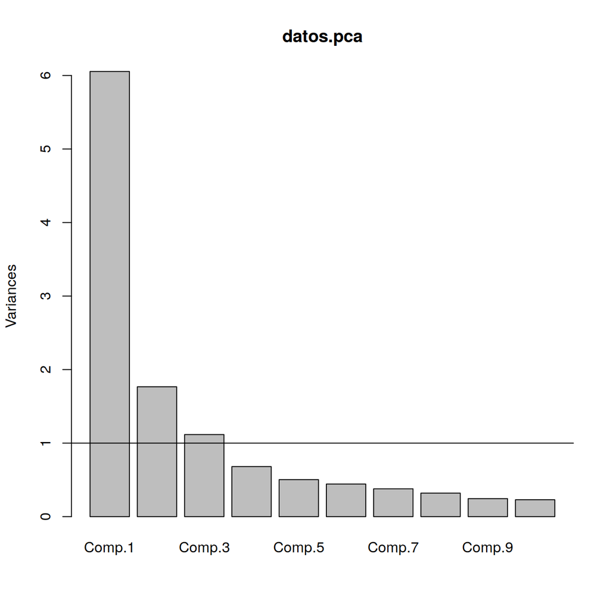

```r
screeplot(datos.pca)
abline(h=mean(R_de$values)) #línea de referencia con correlaciones.
```

Con los primeros tres vectores propios calculamos la matriz de cargas

```r
ind <- 1:3
Lhat <- NULL
for(i in ind) Lhat <- cbind(Lhat,R_de$vectors[ ,i] * sqrt(R_de$values[i])) # arma la matriz de cargas
Lhat  # cargas estimadas
```

```
            [,1]        [,2]        [,3]
 [1,] -0.7830220 -0.43268137  0.31844099
 [2,] -0.7587130 -0.42326441  0.24696993
 [3,] -0.7601838 -0.30245332  0.18710429
 [4,] -0.7657627 -0.36505721  0.28043397
 [5,] -0.7476778  0.55449258  0.05242176
 [6,] -0.6802637  0.56995251  0.13740479
 [7,] -0.7749969  0.49728851  0.08372673
 [8,] -0.7478787  0.42384656  0.11645423
 [9,] -0.6246821 -0.03833837 -0.50217291
[10,] -0.6312430 -0.06560244 -0.55772397
[11,] -0.6630326 -0.17894464 -0.40539133
[12,] -0.5402939 -0.27998389 -0.26616504
```

```r
#Calculamos la matriz residual
Psihat <- diag(diag(R - (Lhat %*% t(Lhat)))) #matriz de unicidades
Rhat <- Lhat %*% t(Lhat) + Psihat
comunalidades <- diag(Lhat %*% t(Lhat))  #comunalidades
unicidades <- diag(Psihat)  #unicidades
comunalidades
```

```
 [1] 0.9017413 0.8157924 0.7043654 0.7983024 0.8692322 0.8064846 0.8549261 0.7525301 0.6438752 0.7138274 0.6359756 0.4411523
```

```r
unicidades
```

```
 [1] 0.09825873 0.18420761 0.29563455 0.20169756 0.13076783 0.19351537 0.14507385 0.24746993 0.35612478 0.28617257 0.36402444 0.55884771
```

```r
# Calculamos la suma de los cuadrados de la matriz residual y comparamos con la suma de los eigenvalores del 4 al 12:
sum((R - Rhat )^2)
```

```
[1] 0.3453513
```

```r
sum(R_de$values[-ind]^2)
```

```
[1] 1.307401
```

Vemos que el error no es muy grande.

## Usando funciones del paquete *psych*

En lo que sigue terminaremos el análisis usando las funciones del paquete *psych*. La descripción de los datos se puede hacer con más información que la función usual *summary*. Incluso podemos ver una gráfica que muestra las distribuciones individuales de cada variable a través de histogramas en la diagonal, la estimación de la media de cada par de variables, los scatterplots con regresiones en la parte baja y en la parte alta de la matriz las correlaciones.

```r
describe(datos)
```

```
    vars   n mean   sd median trimmed  mad min max range  skew kurtosis   se
p1     1 200 7.41 1.56      8    7.62 1.48   1   9     8 -1.46     2.86 0.11
p2     2 200 7.18 1.66      8    7.40 1.48   1   9     8 -1.12     0.88 0.12
p3     3 200 6.97 1.72      7    7.17 1.48   1   9     8 -1.09     1.07 0.12
p4     4 200 7.20 1.70      8    7.42 1.48   1   9     8 -1.33     2.06 0.12
p5     5 200 5.75 2.00      6    5.89 1.48   1   9     8 -0.53    -0.39 0.14
p6     6 200 5.62 1.98      6    5.76 1.48   1   9     8 -0.55    -0.38 0.14
p7     7 200 5.84 1.87      6    5.98 1.48   1   9     8 -0.60    -0.12 0.13
p8     8 200 6.03 2.12      6    6.20 1.48   1   9     8 -0.70    -0.30 0.15
p9     9 200 6.11 1.86      6    6.28 1.48   1   9     8 -0.84     0.59 0.13
p10   10 200 5.91 2.06      6    6.04 1.48   1   9     8 -0.56    -0.36 0.15
p11   11 200 6.35 1.70      6    6.50 1.48   1   9     8 -0.93     1.37 0.12
p12   12 200 6.81 1.75      7    7.02 1.48   1   9     8 -1.12     1.21 0.12
```

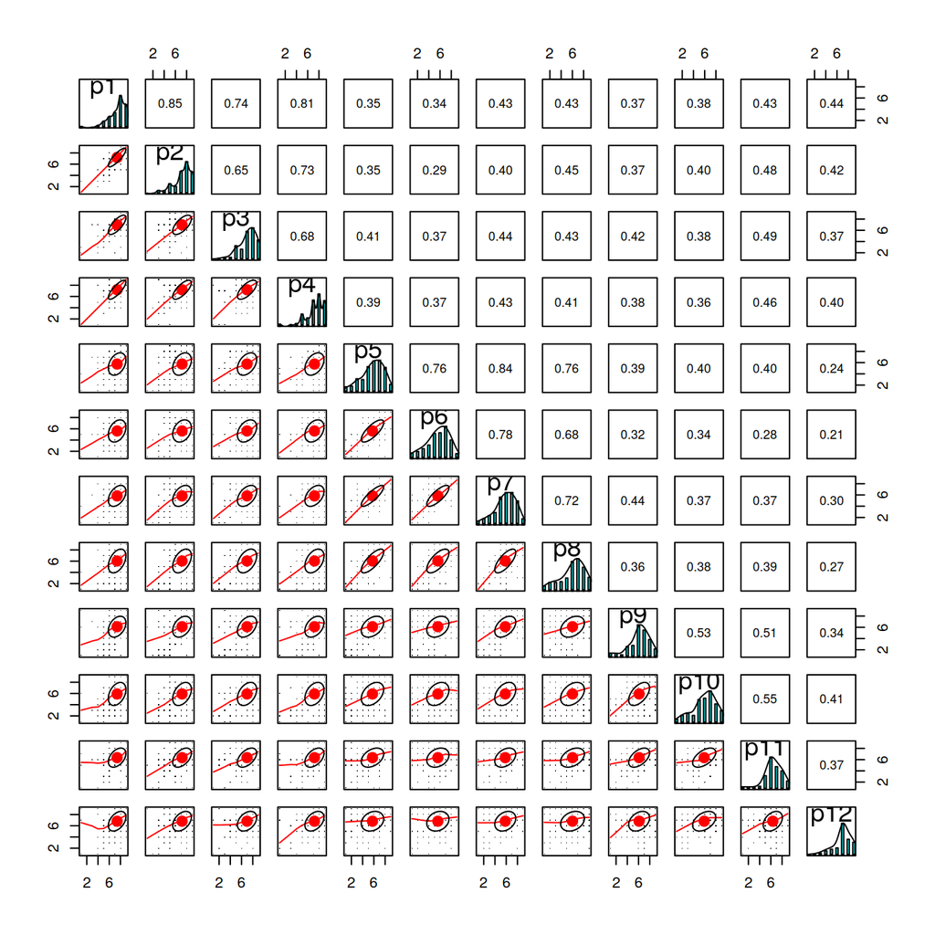

```r
pairs.panels(datos, pch=".")
```

```r
m1 <- pca(r= R, nfactors = 3, rotate = "none")
```

Podemos graficar las componentes principales, para ver cómo se agrupan las variables. Una forma de verlo es usando la función *plot*

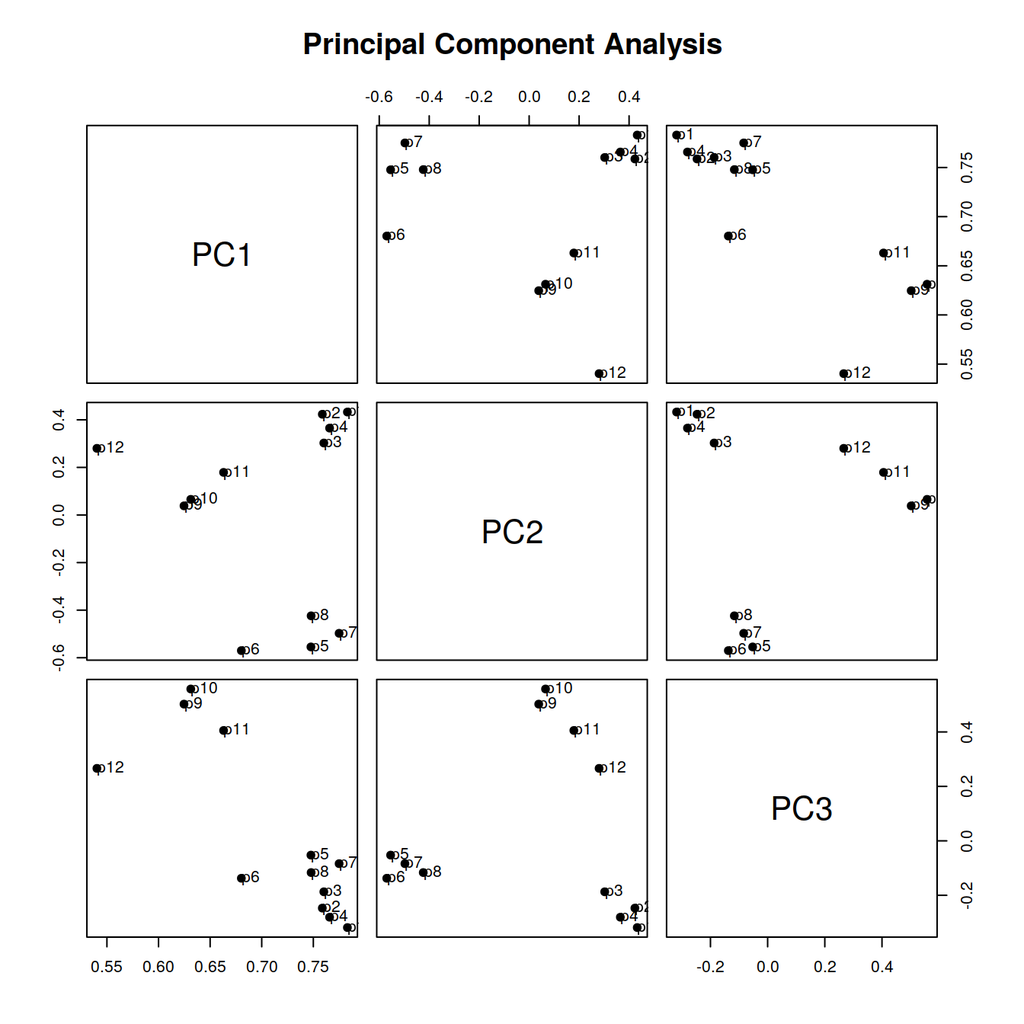

```r
plot(m1,labels = colnames(datos), adj=0) # adj=0 mueve las etiquetas de los puntos a la derecha
```

Seguimos con el análisis de tres factores. Intentemos una rotación varimax para ver si mejora la explicación:

```r
m1varimax <- pca(r= R, nfactors = 3, rotate = "varimax")
m1varimax
```

```
Principal Components Analysis
Call: principal(r = r, nfactors = nfactors, residuals = residuals,
    rotate = rotate, n.obs = n.obs, covar = covar, scores = scores,
    missing = missing, impute = impute, oblique.scores = oblique.scores,
    method = method)
Standardized loadings (pattern matrix) based upon correlation matrix
     RC2  RC1  RC3   h2    u2 com
p1  0.19 0.91 0.21 0.90 0.098 1.2
p2  0.17 0.85 0.25 0.82 0.184 1.3
p3  0.26 0.75 0.28 0.70 0.296 1.5
p4  0.23 0.84 0.22 0.80 0.202 1.3
p5  0.89 0.16 0.23 0.87 0.131 1.2
p6  0.88 0.15 0.12 0.81 0.194 1.1
p7  0.87 0.22 0.23 0.85 0.145 1.3
p8  0.80 0.27 0.20 0.75 0.247 1.4
p9  0.25 0.16 0.75 0.64 0.356 1.3
p10 0.22 0.15 0.80 0.71 0.286 1.2
p11 0.18 0.31 0.71 0.64 0.364 1.5
p12 0.06 0.37 0.55 0.44 0.559 1.8

                       RC2  RC1  RC3
SS loadings           3.29 3.25 2.40
Proportion Var        0.27 0.27 0.20
Cumulative Var        0.27 0.55 0.74
Proportion Explained  0.37 0.36 0.27
Cumulative Proportion 0.37 0.73 1.00

Mean item complexity =  1.3
Test of the hypothesis that 3 components are sufficient.

The root mean square of the residuals (RMSR) is  0.05

Fit based upon off diagonal values = 0.99
```

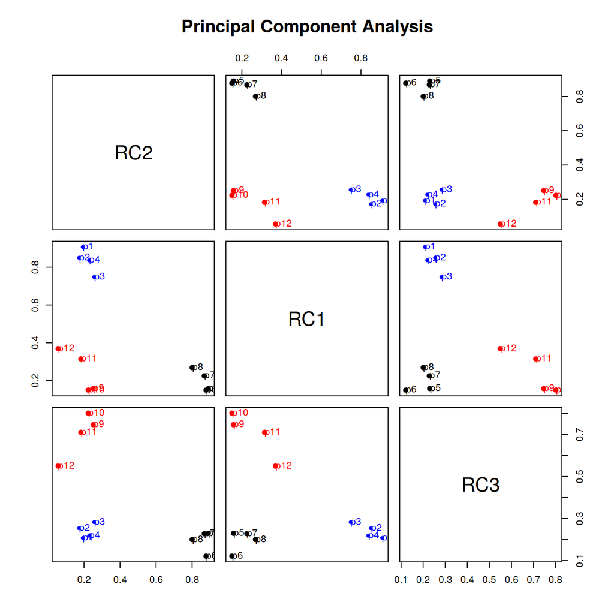

```r
plot(m1varimax,labels = colnames(datos),adj=0)
```

Vemos que en la dirección de esta rotación, las cargas separan mejor los datos, así que se ve más claro la separación de los tres factores.

Ahora consideramos un desarrollo basado en máxima verosimilitud, considerando la rotación varimax. En lugar de utilizar *factanal*, usaré directamente la función *fa*, (los ejemplos con la otra función están en la presentación dada en clase).

La función *fa* nos devuelve mucha más información, pero básicamente llegamos a las mismas conclusiones que en el caso anterior.

```r
mf1 <- fa(r = datos,nfactors = 3,fm = "ml",rotate = "varimax")
mf1
```

```
Factor Analysis using method =  ml
Call: fa(r = datos, nfactors = 3, rotate = "varimax", fm = "ml")
Standardized loadings (pattern matrix) based upon correlation matrix
     ML2  ML1  ML3   h2   u2 com
p1  0.19 0.94 0.20 0.96 0.04 1.2
p2  0.17 0.80 0.29 0.76 0.24 1.4
p3  0.26 0.66 0.33 0.61 0.39 1.8
p4  0.23 0.76 0.27 0.70 0.30 1.5
p5  0.87 0.15 0.26 0.85 0.15 1.2
p6  0.81 0.16 0.14 0.71 0.29 1.1
p7  0.85 0.23 0.23 0.83 0.17 1.3
p8  0.73 0.26 0.24 0.67 0.33 1.5
p9  0.25 0.21 0.61 0.48 0.52 1.6
p10 0.22 0.21 0.67 0.55 0.45 1.4
p11 0.19 0.28 0.68 0.58 0.42 1.5
p12 0.12 0.35 0.40 0.30 0.70 2.1

                       ML2  ML1  ML3
SS loadings           3.03 3.01 1.95
Proportion Var        0.25 0.25 0.16
Cumulative Var        0.25 0.50 0.67
Proportion Explained  0.38 0.38 0.24
Cumulative Proportion 0.38 0.76 1.00

Mean item complexity =  1.5
Test of the hypothesis that 3 factors are sufficient.

The degrees of freedom for the null model are  66  and the objective function was  8.49 with Chi Square of  1647.99
The degrees of freedom for the model are 33  and the objective function was  0.19

The root mean square of the residuals (RMSR) is  0.02
The df corrected root mean square of the residuals is  0.02

The harmonic number of observations is  200 with the empirical chi square  8.18  with prob <  1
The total number of observations was  200  with Likelihood Chi Square =  37.38  with prob <  0.27

Tucker Lewis Index of factoring reliability =  0.994
RMSEA index =  0.029  and the 90 % confidence intervals are  0 0.06
BIC =  -137.47
Fit based upon off diagonal values = 1
Measures of factor score adequacy
                                                   ML2  ML1  ML3
Correlation of (regression) scores with factors   0.95 0.97 0.84
Multiple R square of scores with factors          0.90 0.95 0.70
Minimum correlation of possible factor scores     0.81 0.89 0.41
```

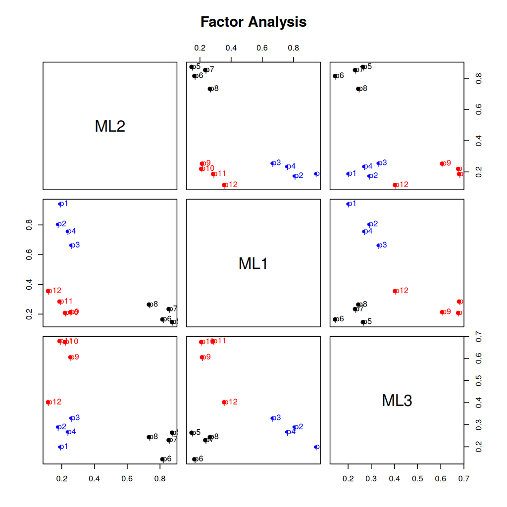

```r
plot(mf1,labels = colnames(datos), adj = 0)
```

Podemos adicionalmente hacer una gráfica que muestre la relación de dependencia de las preguntas a los factores, como un diagrama estructural con las respectivas cargas. Este tipo de diagramas es muy común en modelos estructurales:

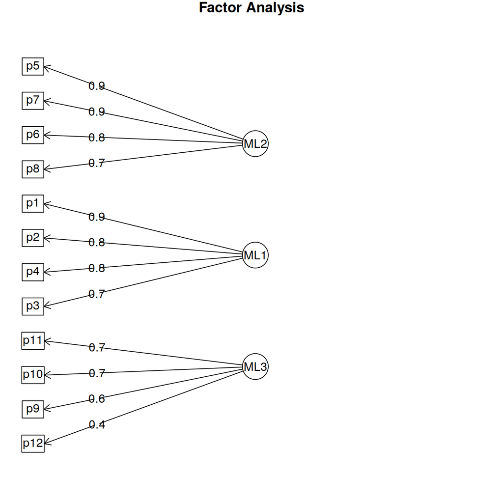

```r
diagram(mf1)
```

Por último, podemos ver una gráfica de biplot. Para eso necesitamos, además de las variables, los scores de los factores (i.e. la estimación de la evaluación de las observaciones en cada factor). Esta gráfica se puede hacer con la función *biplot* del paquete *stats* o la función *biplot.psych* que hace una extensión de las función básica. Ambas en este caso dan básicamente la misma gráfica.

Usaré además la variable que distingue a los profesores de los alumnos para ver sus respectivos scores.

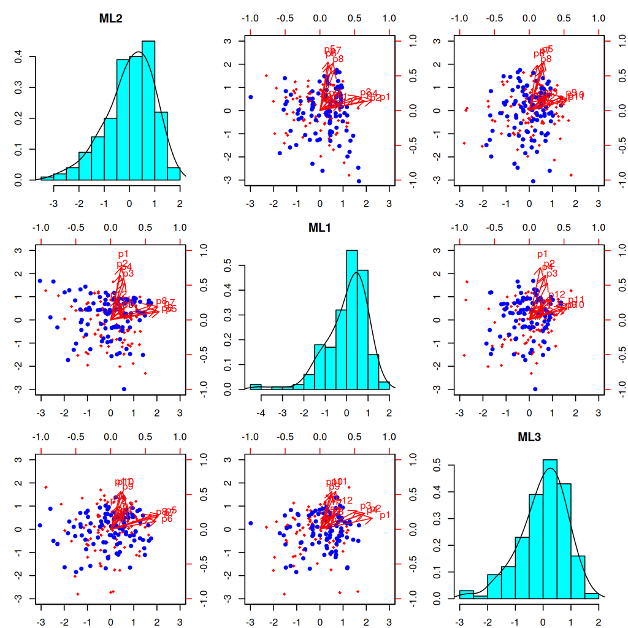

```r
biplot(mf1,group = RoleType)
```

### Referencias

1. Thompson, Bruce (2004) Exploratory and Confirmatory Factor Analysis: Understanding Concepts and Applications. American Psychological Association.